# Analysis of Severe Weather Events on Public Health and Economy in Communities and Municipalities

## Synopsis

In the end, we will show that Tornados cause an overwhelming amount of impact on population health compared to other storm event types, causing 5633 fatalities and 91346 injuries.

Likewise, floods are the most impactful to economic health, causing around 150 billion USD in damage.

## Data Processing

### Dependency Loading

The libraries that are used throughout this document are installed if necessary and then loaded by use of the following dependency function.

```r
depend <- function (s) {
    if (s %in% rownames(installed.packages()) == FALSE) {
        install.packages(s, repos="http://cran.rstudio.com/", dependencies=TRUE)
    }
    library(s, character.only=TRUE)
}
```

### Obtaining and loading source data

- [Storm Data](https://d396qusza40orc.cloudfront.net/repdata%2Fdata%2FStormcsv.bz2) used in this analysis

To load this data, we request the raw CSV file from the remote location and cache it locally. The data is then inspected at a high level by viewing its head, and column names. This information was compared against the documentation found in the following two sources.

- National Weather Service [Storm Data Documentation](https://d396qusza40orc.cloudfront.net/repdata%2Fpeer2_doc%2Fpd01016005curr.pdf)
- National Climatic Data Center Storm Events [FAQ](https://d396qusza40orc.cloudfront.net/repdata%2Fpeer2_doc%2FNCDC%20Storm%20Events-FAQ%20Page.pdf)

A high-level view of the data is included in the output below.

```r
t <- "./storm.csv.bz2"
if (!file.exists(t)) {
    u <- 'https://d396qusza40orc.cloudfront.net/repdata%2Fdata%2FStormcsv.bz2'
    download.file(u,destfile=t, method="curl")
}
dat <- read.table(bzfile(t), na.strings = "NA", header=T, quote="\"", sep=",")
```

```r
colnames(dat);
```

```
##  [1] "STATE__"    "BGN_DATE"   "BGN_TIME"   "TIME_ZONE"  "COUNTY"
##  [6] "COUNTYNAME" "STATE"      "EVTYPE"     "BGN_RANGE"  "BGN_AZI"
## [11] "BGN_LOCATI" "END_DATE"   "END_TIME"   "COUNTY_END" "COUNTYENDN"
## [16] "END_RANGE"  "END_AZI"    "END_LOCATI" "LENGTH"     "WIDTH"
## [21] "F"          "MAG"        "FATALITIES" "INJURIES"   "PROPDMG"
## [26] "PROPDMGEXP" "CROPDMG"    "CROPDMGEXP" "WFO"        "STATEOFFIC"
## [31] "ZONENAMES"  "LATITUDE"   "LONGITUDE"  "LATITUDE_E" "LONGITUDE_"
## [36] "REMARKS"    "REFNUM"
```

```r
head(dat);
```

```
##   STATE__           BGN_DATE BGN_TIME TIME_ZONE COUNTY COUNTYNAME STATE
## 1       1  4/18/1950 0:00:00     0130       CST     97     MOBILE    AL
## 2       1  4/18/1950 0:00:00     0145       CST      3    BALDWIN    AL
## 3       1  2/20/1951 0:00:00     1600       CST     57    FAYETTE    AL
## 4       1   6/8/1951 0:00:00     0900       CST     89    MADISON    AL
## 5       1 11/15/1951 0:00:00     1500       CST     43    CULLMAN    AL
## 6       1 11/15/1951 0:00:00     2000       CST     77 LAUDERDALE    AL
##    EVTYPE BGN_RANGE BGN_AZI BGN_LOCATI END_DATE END_TIME COUNTY_END
## 1 TORNADO         0                                               0
## 2 TORNADO         0                                               0
## 3 TORNADO         0                                               0
## 4 TORNADO         0                                               0
## 5 TORNADO         0                                               0
## 6 TORNADO         0                                               0
##   COUNTYENDN END_RANGE END_AZI END_LOCATI LENGTH WIDTH F MAG FATALITIES
```

[output cut: 20 more lines]

### Data transformations

For the following transformations, I’m loading and using the [dplyr](https://cran.r-project.org/web/packages/dplyr/index.html) and [lubridate](https://cran.r-project.org/web/packages/lubridate/index.html) libraries.

```r
depend('dplyr')
depend('lubridate')
```

Grouping all the data by event type then allows for easy summarization by fatalities and injuries. I have sorted the data to show the most impactful event types first. This data frame will be used to plot a figure analyzing the events with the greatest effect on population health, below.

*Note: There are many variations of factors in the EVTYPE column. Some of these variations appear to be referring to the same type of storm event, however, they are not documented as such in the supporting documentation and have been left as-is intentionally as a result.*

```r
pop_health <- dat %>%
    group_by(EVTYPE) %>%
    summarize(TOTAL_FATALITIES=sum(FATALITIES),
              TOTAL_INJURIES=sum(INJURIES)) %>%
    arrange(desc(TOTAL_FATALITIES), desc(TOTAL_INJURIES))

head(pop_health)
```

```
## Source: local data frame [6 x 3]
##
##           EVTYPE TOTAL_FATALITIES TOTAL_INJURIES
## 1        TORNADO             5633          91346
## 2 EXCESSIVE HEAT             1903           6525
## 3    FLASH FLOOD              978           1777
## 4           HEAT              937           2100
## 5      LIGHTNING              816           5230
## 6      TSTM WIND              504           6957
```

Calculating economic impact is a degree more difficult. There are several fields related to this measurement: PROPDMG, PROPDMGEXP, CROPDMG, and CROPDMGEXP. The PROPDMG and CROPDMG columns represent property and crop damages in dollar values, respectively. The EXP columns give the order of magnitude of those damages, ranging from thousands to billions. Unfortunately, these exponent columns are very un-tidy, as demonstrated by listing their factor levels:

```r
levels(factor(dat$PROPDMGEXP))
```

```
##  [1] ""  "-" "?" "+" "0" "1" "2" "3" "4" "5" "6" "7" "8" "B" "h" "H" "K"
## [18] "m" "M"
```

To correct this, we need to carefully adjust all of these values to a single numeric multiplier. Empty strings will get a 0 value. Symbols get a 1 value. H (hundreds), K (thousands), M (millions), and B (billions) will get their respective 2,3,6, or 9. Finally, to make sure our multiplication works, we’ll set any empty damage numbers to 0.

```r
# replace missing data with 0's
dat$PROPDMGEXP <- as.character(dat$PROPDMGEXP)
dat$CROPDMGEXP <- as.character(dat$CROPDMGEXP)

dat$PROPDMGEXP[(dat$PROPDMGEXP == "")] <- 0
dat$PROPDMGEXP[(dat$PROPDMGEXP == "+") | (dat$PROPDMGEXP == "-") | (dat$PROPDMGEXP == "?")] <- 1
dat$PROPDMGEXP[(dat$PROPDMGEXP == "h") | (dat$PROPDMGEXP == "H")] <- 2
dat$PROPDMGEXP[(dat$PROPDMGEXP == "k") | (dat$PROPDMGEXP == "K")] <- 3
dat$PROPDMGEXP[(dat$PROPDMGEXP == "m") | (dat$PROPDMGEXP == "M")] <- 6
dat$PROPDMGEXP[(dat$PROPDMGEXP == "B")] <- 9

dat$CROPDMGEXP[(dat$CROPDMGEXP == "")] <- 0
dat$CROPDMGEXP[(dat$CROPDMGEXP == "+") | (dat$CROPDMGEXP == "-") | (dat$CROPDMGEXP == "?")] <- 1
dat$CROPDMGEXP[(dat$CROPDMGEXP == "h") | (dat$CROPDMGEXP == "H")] <- 2
dat$CROPDMGEXP[(dat$CROPDMGEXP == "k") | (dat$CROPDMGEXP == "K")] <- 3
dat$CROPDMGEXP[(dat$CROPDMGEXP == "m") | (dat$CROPDMGEXP == "M")] <- 6
dat$CROPDMGEXP[(dat$CROPDMGEXP == "B")] <- 9

dat$PROPDMGEXP <- as.integer(dat$PROPDMGEXP)
dat$CROPDMGEXP <- as.integer(dat$CROPDMGEXP)

dat$PROPDMG[(dat$PROPDMG == "")] <- 0
dat$CROPDMG[(dat$CROPDMG == "")] <- 0
```

```r
trans_damage <- dat %>%
    mutate(TOTAL_DMG=(PROPDMG * 10^PROPDMGEXP + CROPDMG * 10^CROPDMGEXP)) %>%
    group_by(EVTYPE) %>%
    summarize(EVT_TOTAL_DMG=sum(TOTAL_DMG)) %>%
    arrange(desc(EVT_TOTAL_DMG))

head(trans_damage)
```

```
## Source: local data frame [6 x 2]
##
##              EVTYPE EVT_TOTAL_DMG
## 1             FLOOD     1.503e+11
## 2 HURRICANE/TYPHOON     7.191e+10
## 3           TORNADO     5.736e+10
## 4       STORM SURGE     4.332e+10
## 5              HAIL     1.876e+10
## 6       FLASH FLOOD     1.824e+10
```

## Results

```r
depend('ggplot2')
depend('ggthemes')
depend('scales')
```

### Events most harmful to population health

*Across the United States, which types of events (as indicated in the EVTYPE variable) are most harmful with respect to population health?*

Plotting the top 10 event types by total fatalities and total injuries clearly shows tornados as the leading impact to population health.

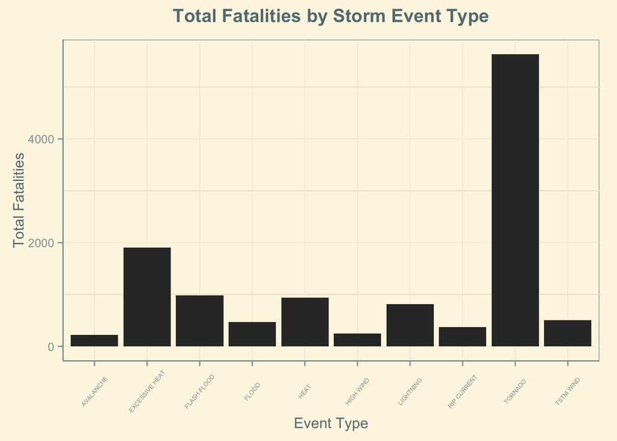

```r
fatal_pop_health = head(pop_health %>% arrange(desc(TOTAL_FATALITIES)), 10)
ggplot(fatal_pop_health, aes(EVTYPE, TOTAL_FATALITIES) ) +
    geom_bar(stat = "identity") +
    theme_solarized() +
    scale_colour_solarized("red") +
    labs(x="Event Type", y="Total Fatalities", title="Total Fatalities by Storm Event Type") +
    theme(plot.title=element_text(size=15, face="bold", vjust=2)) +
    theme(legend.title=element_blank()) +
    theme(axis.text.x=element_text(angle=50, size=5, vjust=0.5))
```

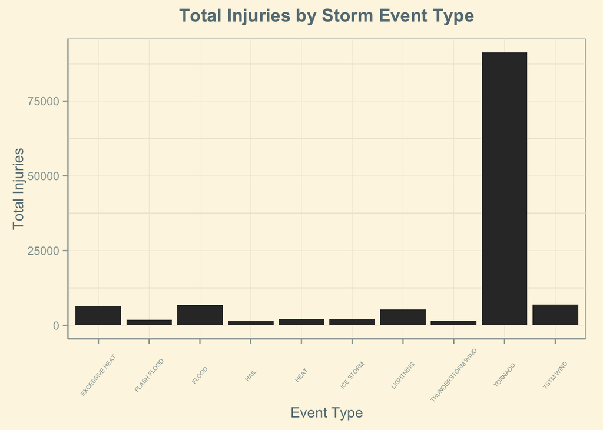

```r
inj_pop_health = head(pop_health %>% arrange(desc(TOTAL_INJURIES)), 10)
ggplot(inj_pop_health, aes(EVTYPE, TOTAL_INJURIES) ) +
    geom_bar(stat = "identity") +
    theme_solarized() +
    scale_colour_solarized("red") +
    labs(x="Event Type", y="Total Injuries", title="Total Injuries by Storm Event Type") +
    theme(plot.title=element_text(size=15, face="bold", vjust=2)) +
    theme(legend.title=element_blank()) +
    theme(axis.text.x=element_text(angle=50, size=5, vjust=0.5))
```

```r
pop_health[pop_health$EVTYPE=="TORNADO",]
```

```
## Source: local data frame [1 x 3]
##
##    EVTYPE TOTAL_FATALITIES TOTAL_INJURIES
## 1 TORNADO             5633          91346
```

### Events with greatest economic consequences

*Across the United States, which types of events have the greatest economic consequences?*

When the damage numbers have been properly adjusted and combined, the most damaging type is flooding. Several of the top 10 event types overlap in naming, but are all closely related. Flooding alone has caused more than 150 billion dollars in damages.

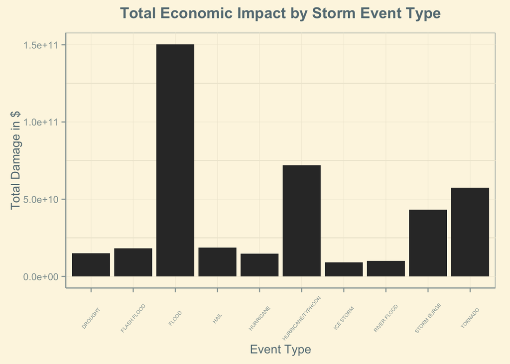

```r
trans_damage = head(trans_damage %>% arrange(desc(EVT_TOTAL_DMG)), 10)
ggplot(trans_damage, aes(EVTYPE, EVT_TOTAL_DMG) ) +
    geom_bar(stat = "identity") +
    theme_solarized() +
    scale_colour_solarized("red") +
    labs(x="Event Type", y="Total Damage in $", title="Total Economic Impact by Storm Event Type") +
    theme(plot.title=element_text(size=15, face="bold", vjust=2)) +
    theme(legend.title=element_blank()) +
    theme(axis.text.x=element_text(angle=50, size=5, vjust=0.5))
```

```r
trans_damage[trans_damage$EVTYPE=="FLOOD",]
```

```
## Source: local data frame [1 x 2]
##
##   EVTYPE EVT_TOTAL_DMG
## 1  FLOOD     1.503e+11
```